# Project 2. EFA

## Outliers and Leverages

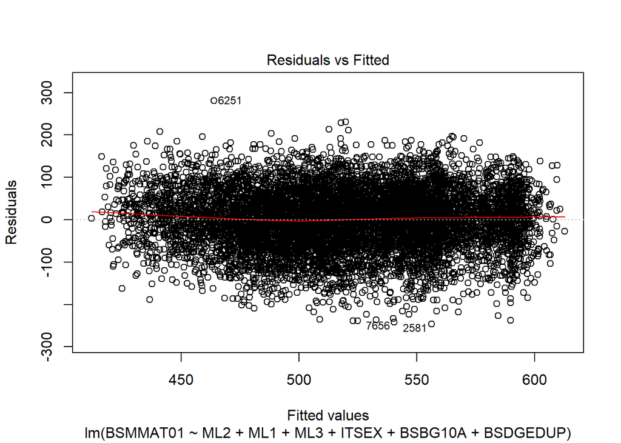

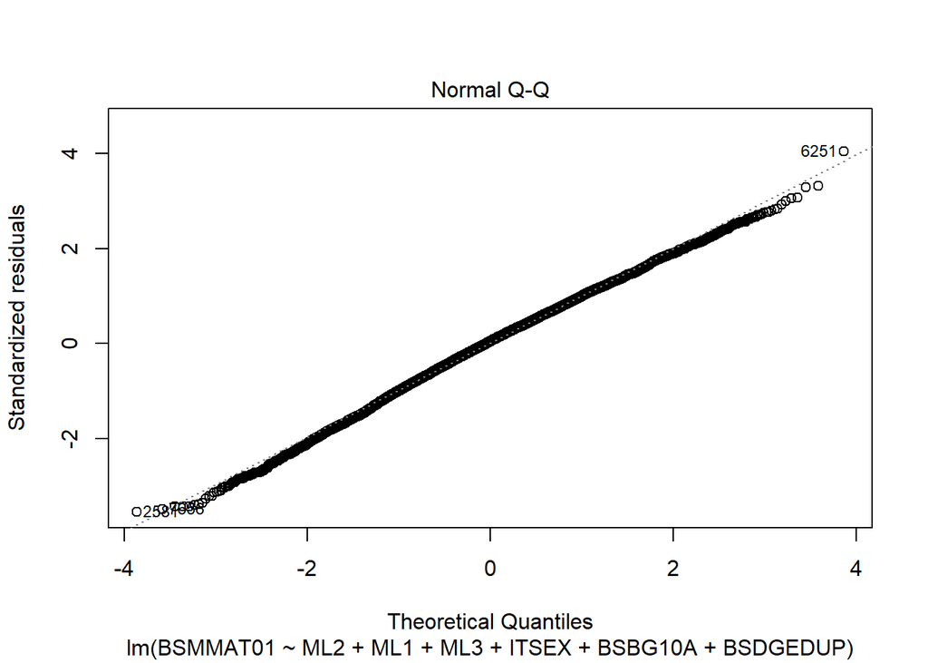

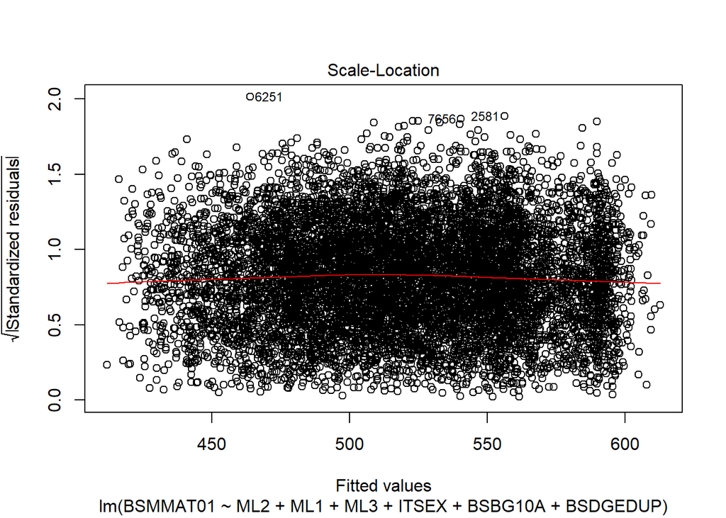

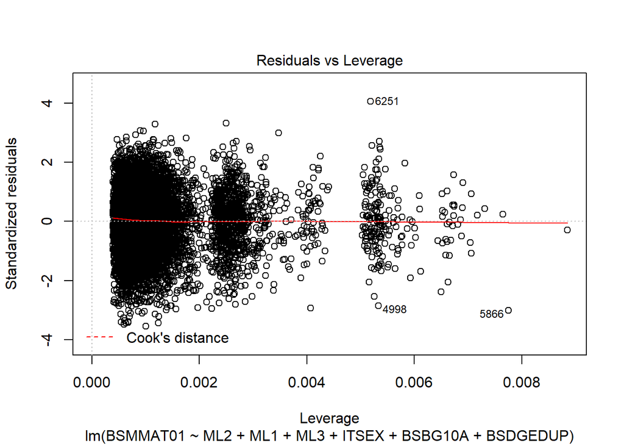

```r
plot(model.reg)
```

According to plots above, I can make these conclusions: - The distribution of residuals is normal, they fit the staraight line almost perfectly - There are no leverages, because they do not cross Cook’s distance line

# Conclusion

The research helped to find factors which are dedicated to investigating the attitude towards math science, and showed how these factors influence the math achievement of students in USA. First, I confirmed the hypothesis, that self-perception of higher abilities in math increase the score of math achievement of a student. Second, I found that lower education level of parents decreases the math achievement score of a student. Third, there is no significant difference in math achievements between males and females. These are the most important conclusions which this research have shown.